# Analysis of pharmacotherapy for colon carcinoma

Weiling

2022-05-10

## R Markdown

```r
r = getOption("repos")
r["CRAN"] = "http://cran.us.r-project.org"
options(repos = r)
install.packages("weatherData")
library(survival)
install.packages("readxl")
library(readxl)
daata <- read.csv("/Users/a11/Documents/survcolon.csv")
```

## 年齡分組

```r
daata$age <- as.numeric(daata$age)  #*
daata$age_gp = cut(daata$age, c(0, 10, 20, 30, 40, 50, 60, 70, 80, 90))
summary(daata$age_gp)
```

```
##  (0,10] (10,20] (20,30] (30,40] (40,50] (50,60] (60,70] (70,80] (80,90]
##       0       1      13      64     119     248     303     172       9
```

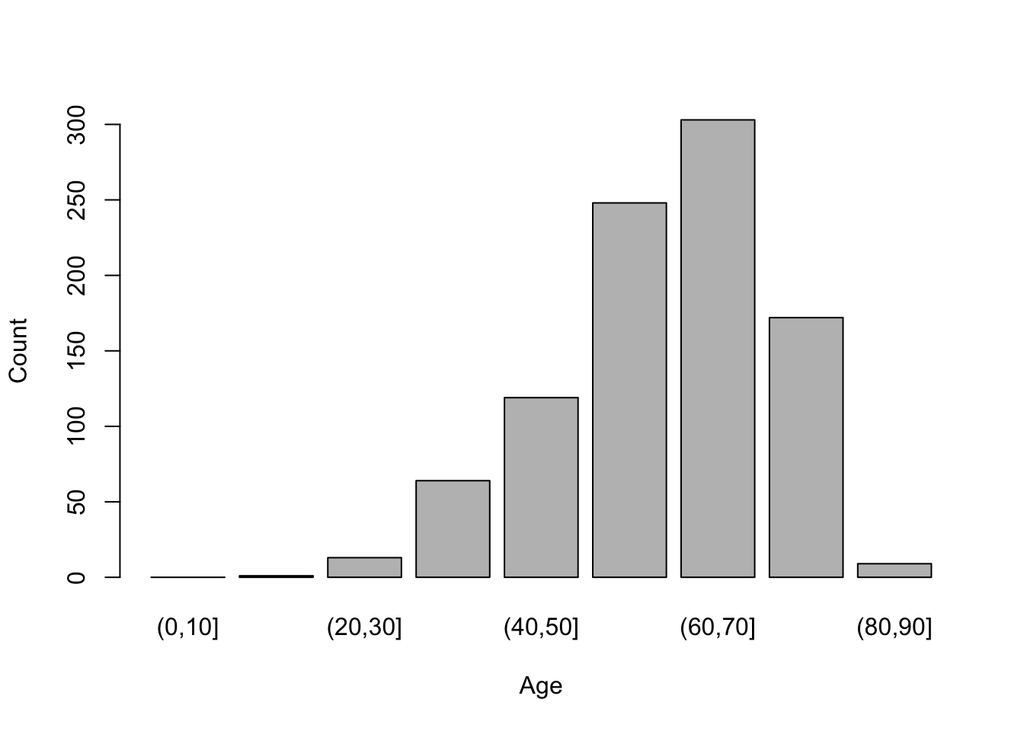

```r
barplot(summary(daata$age_gp),xlab="Age", ylab="Count")
```

*大腸癌的好發年齡:可看出在50歲以後急速成長，並在60-70時達到高峰*

## 性別

```r
summary(factor(daata$sex))
```

```
##   0   1
## 445 484
```

*男:484, 女:445 (男性人數略高於女性)*

### 做log-rank檢定

```r
test1=survdiff(Surv(time,lastcens) ~factor(sex), data=daata)
test1
```

```
## Call:
## survdiff(formula = Surv(time, lastcens) ~ factor(sex), data = daata)
##
##                 N Observed Expected (O-E)^2/E (O-E)^2/V
## factor(sex)=0 445      215      217   0.01049    0.0202
## factor(sex)=1 484      237      235   0.00965    0.0202
##
##  Chisq= 0  on 1 degrees of freedom, p= 0.9
```

### 畫存活曲線圖

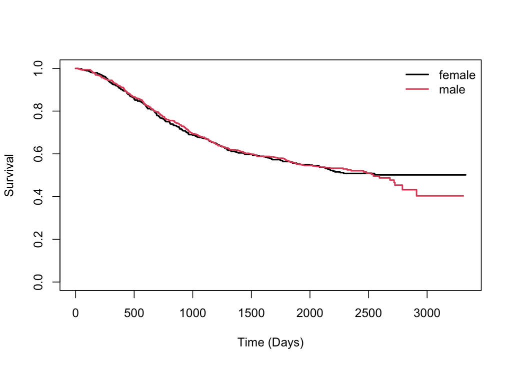

```r
km1 = survfit(Surv(time,lastcens) ~sex, data=daata,
              type="kaplan-meier", error="greenwood", conf.type=c("plain"))
plot(km1, lwd=2, col=c(1:2), mark.time=F,
     xlab="Time (Days)", ylab="Survival")
legend("topright", c("female","male"),
       lwd=2, col=c(1:2), bty="n")
```

```r
#summary(km1)
```

*從一開始兩條線都很靠近，約在2600天後才看出差異變大*

## 治療組別

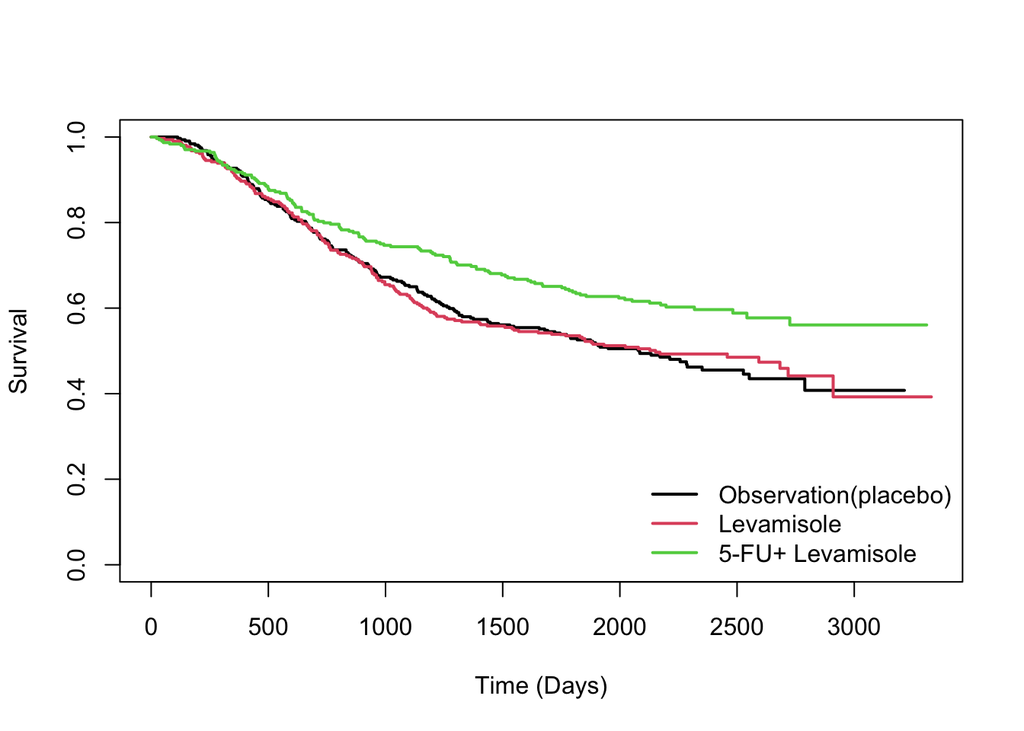

```r
km2 = survfit(Surv(time,lastcens) ~treat, data=daata,
             type="kaplan-meier", error="greenwood", conf.type=c("plain"))
plot(km2, lwd=2, col=c(1:3), mark.time=F,
     xlab="Time (Days)", ylab="Survival")
legend("bottomright", c("Observation(placebo)","Levamisole","5-FU+ Levamisole"), lwd=2, col=c(1:3), bty="n")
```

```r
#summary(km2)
```

*使用placebo(葡萄糖)與使用Levamisole看起來沒有明顯差異* *5-FU + Levamisole的存活曲線皆高於其他兩組*

## 侵犯程度

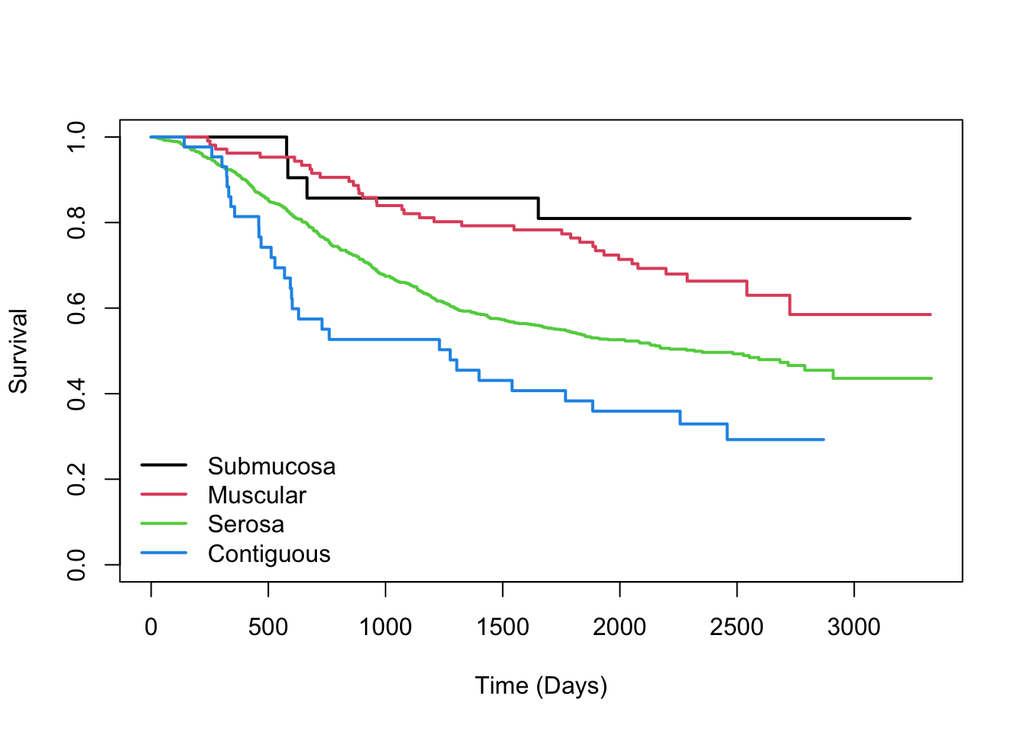

```r
km3 = survfit(Surv(time,lastcens) ~factor(extent), data=daata,
              type="kaplan-meier", error="greenwood", conf.type=c("plain"))
plot(km3, lwd=2, col=c(1:4), mark.time=F, xlab="Time (Days)", ylab="Survival")
legend("bottomleft", c("Submucosa","Muscular","Serosa","Contiguous"), lwd=2, col=c(1:4), bty="n") #"黏膜下層","肌肉層","漿膜層","接觸結構"
```

*侵犯程度越嚴重的，survival就越小*

## 4. 治療組別

## 做log-rank檢定

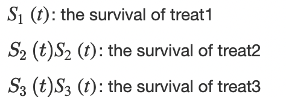

```r
knitr::include_graphics('/Users/a11/Desktop/截圖\ 2022-07-21\ 下午3.01.29.png')
```

## (1)

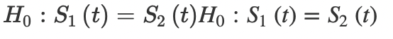

```r
knitr::include_graphics('/Users/a11/Desktop/截圖\ 2022-07-21\ 下午3.05.54.png')
```

```r
treat12 = daata[daata$treat!="3",]  # 只留下treat1 & treat2
treat13 = daata[daata$treat!="2",]  # 只留下treat1 & treat3
treat23 = daata[daata$treat!="1",]  # 只留下treat2 & treat3
test12 = survdiff(Surv(time,lastcens) ~factor(treat), data=treat12)
test12
```

```
## Call:
## survdiff(formula = Surv(time, lastcens) ~ factor(treat), data = treat12)
##
##                   N Observed Expected (O-E)^2/E (O-E)^2/V
## factor(treat)=1 315      168      166    0.0282     0.057
## factor(treat)=2 310      161      163    0.0287     0.057
##
##  Chisq= 0.1  on 1 degrees of freedom, p= 0.8
```

### p= 0.8 > 0.05，代表使用placebo(葡萄糖)v.s.使用Levamisole治療沒有顯著差異

## (2)

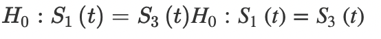

```r
knitr::include_graphics('/Users/a11/Desktop/截圖\ 2022-07-21\ 下午3.08.44.png')
```

```r
test13 = survdiff(Surv(time,lastcens) ~factor(treat), data=treat13)
test13
```

```
## Call:
## survdiff(formula = Surv(time, lastcens) ~ factor(treat), data = treat13)
##
##                   N Observed Expected (O-E)^2/E (O-E)^2/V
## factor(treat)=1 315      168      141      5.12      9.97
## factor(treat)=3 304      123      150      4.82      9.97
##
##  Chisq= 10  on 1 degrees of freedom, p= 0.002
```

### p= 0.002 < 0.05，代表使用placebo(葡萄糖)v.s.使用5-FU + Levamisole治療有顯著差異

## (3)

[figure not shown]

```r
knitr::include_graphics('/Users/a11/Desktop/截圖\ 2022-07-21\ 下午3.08.44.png')
```

```r
test23 = survdiff(Surv(time,lastcens) ~factor(treat), data=treat23)
test23
```

```
## Call:
## survdiff(formula = Surv(time, lastcens) ~ factor(treat), data = treat23)
##
##                   N Observed Expected (O-E)^2/E (O-E)^2/V
## factor(treat)=2 310      161      137      4.24      8.21
## factor(treat)=3 304      123      147      3.95      8.21
##
##  Chisq= 8.2  on 1 degrees of freedom, p= 0.004
```

### p= 0.004 < 0.05，代表使用Levamisole治療v.s.同時使用5-FU + Levamisole治療有顯著差異

## 治療組別

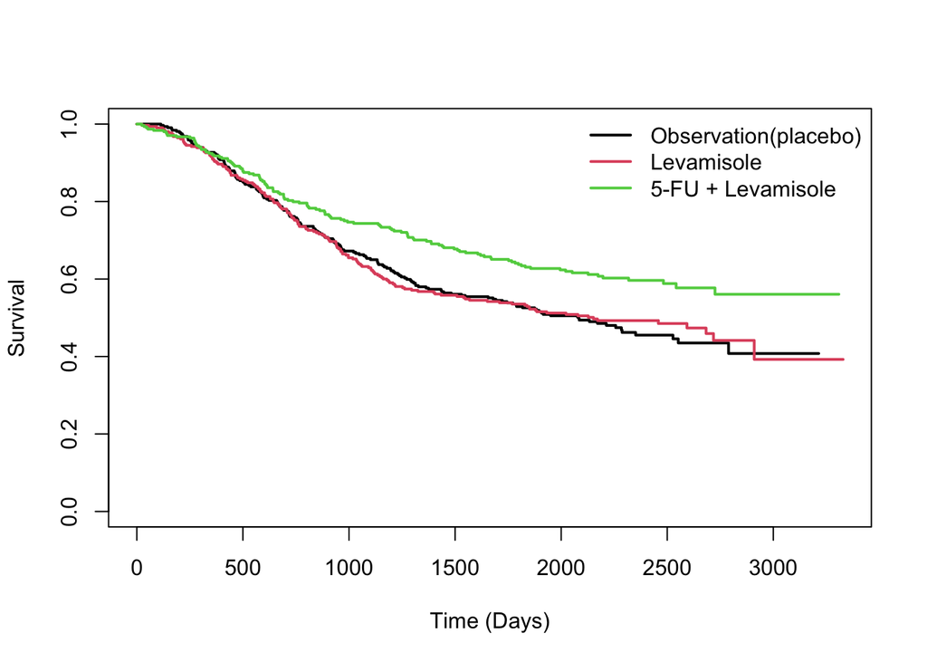

```r
km2 = survfit(Surv(time,lastcens) ~treat, data=daata,
             type="kaplan-meier", error="greenwood",
             conf.type=c("plain"))
plot(km2, lwd=2, col=c(1:3), mark.time=F, xlab="Time (Days)", ylab="Survival")
legend("topright", c("Observation(placebo)","Levamisole","5-FU + Levamisole"),
       lwd=2, col=c(1:3), bty="n")
```

### 使用placebo(葡萄糖)與使用Levamisole看起來沒有明顯差異 ### 5-FU + Levamisole的存活曲線皆高於其他兩組 ### 可知，要同時使用5-FU和Levamisole才能有效改善死亡率

## fit Cox model(treat2 v.s. treat3)

```r
coxfit1 = coxph(Surv(time,lastcens) ~factor(treat), data=treat23,
                ties=c("breslow"))
coxfit1
```

```
## Call:
## coxph(formula = Surv(time, lastcens) ~ factor(treat), data = treat23,
##     ties = c("breslow"))
##
##                   coef exp(coef) se(coef)      z       p
## factor(treat)3 -0.3417    0.7106   0.1199 -2.851 0.00436
##
## Likelihood ratio test=8.21  on 1 df, p=0.004165
## n= 614, number of events= 284
```

## Levamisole治療v.s.同時使用5-FU + Levamisole治療是否風險成比例

### (1)畫圖

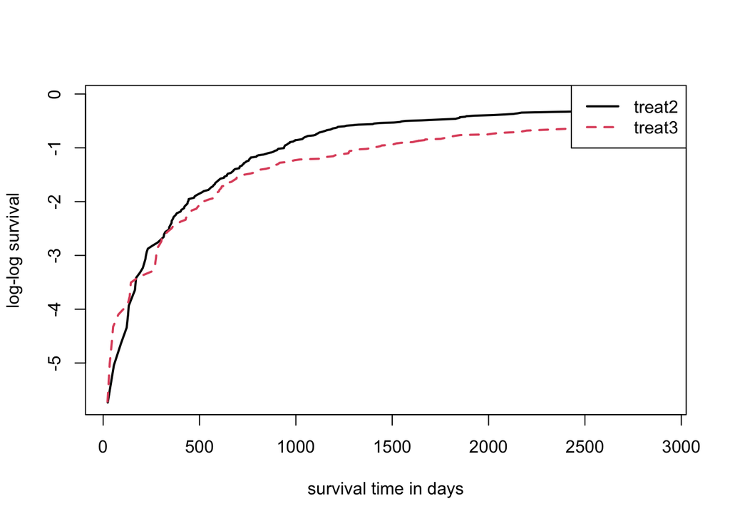

```r
sumkm2 = summary(km2)
testkm2 = data.frame(sumkm2$strata, sumkm2$time, sumkm2$surv)
names(testkm2) = c("treat", "time", "survival")
testtreat2 = testkm2[testkm2$treat=="treat=2",]
testtreat3 = testkm2[testkm2$treat=="treat=3",]

plot(testtreat2$time, log(-log(testtreat2$survival)),
     xlab="survival time in days",
     ylab="log-log survival",
     type="l", lwd=2, lty=1)
points((testtreat3$time), log(-log(testtreat3$survival)),
       type="l", lty=2, lwd=2, col=2)
legend("topright", c("treat2", "treat3"), lwd=2, lty=c(1,2), col=c(1,2))
```

## (2)The Goodness of Fit Testing Approach (GOF)

```r
coxfit1 = coxph(Surv(time,lastcens) ~factor(treat), data=treat23, ties=c("breslow"))
gof = cox.zph(coxfit1, transform="rank")
gof
```

```
##               chisq df    p
## factor(treat)  0.14  1 0.71
## GLOBAL         0.14  1 0.71
```

## 都不拒絕H0，代表殘差跟時間無關，PH假設OK

## 所以根據上面coxfit1的結果，我們可以說同時使用5-FU + Levamisole的風險是只有使用Levamisole的0.7106倍

### 個體組織型態

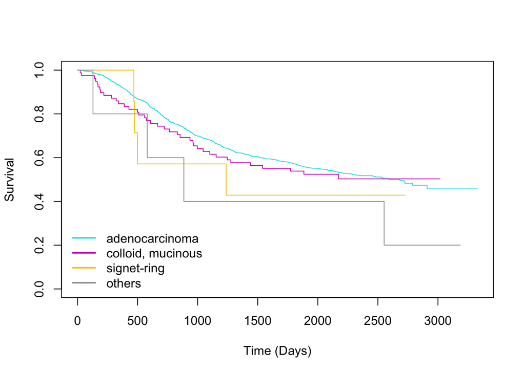

```r
km5 = survfit(Surv(time,lastcens) ~factor(hist), data=daata,type="kaplan-meier", error="greenwood", conf.type=c("plain"))
plot(km5, lwd=1, col=c(5:8), mark.time=F,xlab="Time (Days)",
     ylab="Survival")
legend("bottomleft", c("adenocarcinoma","colloid, mucinous","signet-ring","others"),
      lwd=2, col=c(5:8), bty="n") #"線狀細胞","黏液細胞","指環狀細胞","其他" #＊"指環狀細胞"和"其他"為明顯階梯，因為其資料分別只有7和5個，因此差距甚大。而"線狀細胞"和"黏液細胞"沒有很明顯的差異。排除此兩個組別(hist=3,hist=4)，下面開始比較hist=1,hist=2。
```

### Adenocarcinoma為線狀細胞是超過百分之90的大腸癌起源於結直腸黏膜上皮細胞的腺癌。 ### Mucinous為黏液細胞，這種特殊類型的大腸癌定義為大於百分之50的腫瘤體積由細胞外粘蛋白組成。

```r
install.packages("survminer")
library(survminer)
```

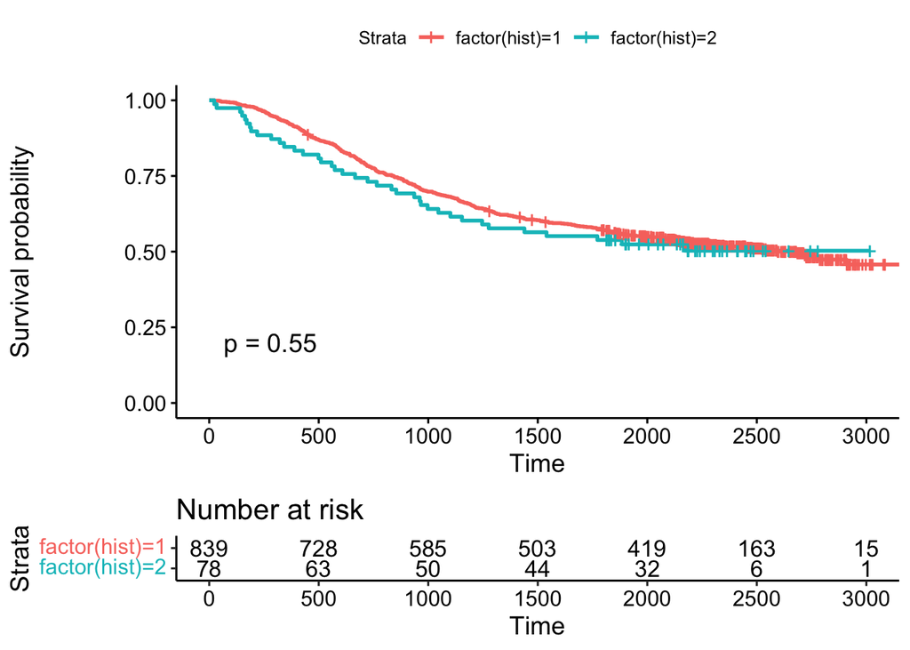

```r
hist123 = daata[daata$hist!="4",]
hist12 = hist123[hist123$hist!="3",]
km_hist12 = survfit(Surv(time,lastcens) ~factor(hist), data=hist12)
ggsurvplot(km_hist12,pval=TRUE,risk.table  = TRUE,break.time.by=500)
```

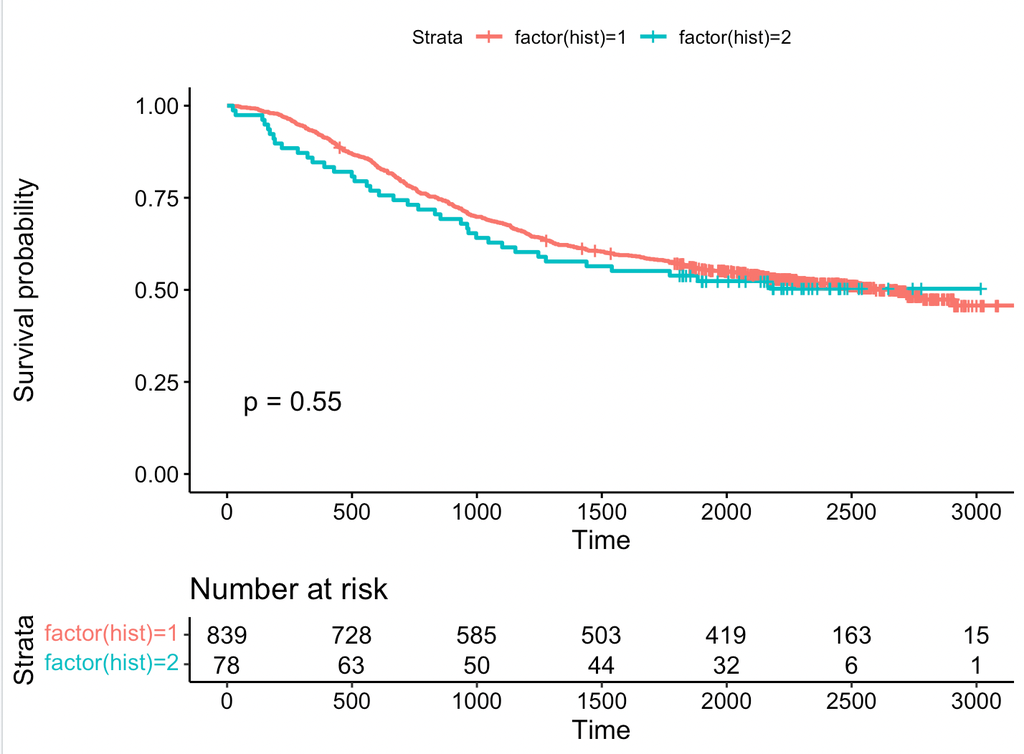

```r
knitr::include_graphics('/Users/a11/Desktop/截圖\ 2022-07-21\ 下午4.17.00.png')
```

```r
cox_hist12=coxph(formula = Surv(time,lastcens)~factor(hist),data=hist12,method="breslow")
summary(cox_hist12)
```

```
## Call:
## coxph(formula = Surv(time, lastcens) ~ factor(hist), data = hist12,
##     method = "breslow")
##
##   n= 917, number of events= 444
##
##                 coef exp(coef) se(coef)     z Pr(>|z|)
## factor(hist)2 0.1007    1.1060   0.1697 0.594    0.553
##
##               exp(coef) exp(-coef) lower .95 upper .95
## factor(hist)2     1.106     0.9042     0.793     1.542
##
## Concordance= 0.507  (se = 0.007 )
## Likelihood ratio test= 0.34  on 1 df,   p=0.6
## Wald test            = 0.35  on 1 df,   p=0.6
## Score (logrank) test = 0.35  on 1 df,   p=0.6
```

## 進行cox分析發現黏液細胞相比線狀細胞的風險為1.106倍，差異不是太大。